**Instructor copy.** Executed notebook with all results shown, including the "after your attempt" cells. Projector/offline fallback; learners should use the notebook itself.

# f4 · Two phases: common tangent, lever rule and phase diagrams

**Learning question:** when does a sample split into two regions, which compositions do they take, how much of each forms, and how do these answers at many temperatures draw a phase diagram?

Used in: Lessons 5, 7; self-study step 03 (parts A, B, C) and step 07 (optional). Work each "your turn" on paper first, then type your value. Labels such as (W4), (D1), (Lesson 5) or Clinic D point to the printed one-day primers (Day 1 and Day 2 worksheets) and the detailed lessons of the classroom course in the repository. Working alone on the website, you only need the step numbers.

**The plan.** f3 built the Gibbs-energy curve of *one* phase and read chemical potentials from its tangent. Here a sample may divide into two regions, and we ask whether that lowers the total Gibbs energy.

- **Part A** (sections 1 and 2): two different phases, ALPHA and BETA. The lever rule counts the atoms, the common tangent picks the compositions, and a linear programme shows how a computer finds them.
- **Part B** (section 3): one phase model whose curve has a hump, so the sample splits into two coexisting phases described by the *same* phase model (a miscibility gap). Repeating the calculation at many temperatures draws a phase diagram.
- **Part C** (section 4): a SOLID and a LIQUID, which together give the melting "lens" diagram.

```python
# Setup: run this cell first. Locally it finds the course folder; in Colab it
# downloads the tested course release and the locked package versions.
# In Colab, the first run then restarts the session on purpose and Colab reports
# a crash: that is expected. Run this cell again, then the rest of the notebook.
RELEASE = "main"
import os, pathlib, subprocess, sys, time
ROOT = next((p for p in (pathlib.Path.cwd(), *pathlib.Path.cwd().parents)
             if (p / "pyproject.toml").is_file() and (p / "course").is_dir()), None)
if ROOT is None and "google.colab" in sys.modules:
    ROOT = pathlib.Path("/content/CalphadIntro")
    if not ROOT.is_dir():
        clone = ["git", "clone", "-q", "--depth", "1", "--branch", RELEASE,
                 "https://github.com/ukerzel/CalphadIntro.git", str(ROOT)]
        git = dict(os.environ, GIT_TERMINAL_PROMPT="0")
        if subprocess.run(clone, env=git, capture_output=True).returncode:
            raise SystemExit(f"Could not download course release {RELEASE}: check the internet "
                             "connection and run this cell again.")
    if not (ROOT / ".colab-ready").exists():
        if subprocess.run([sys.executable, "-m", "pip", "install", "-q", "-r",
                           str(ROOT / "notebooks" / "requirements-colab.txt")]).returncode:
            raise SystemExit("Installing the course packages failed; run this cell again.")
        (ROOT / ".colab-ready").touch()
        # Colab has already loaded its own numpy; a fresh session is needed to use the installed versions.
        print("Installed the course's package versions. Colab now restarts this session and"
              " reports a crash; that is expected. When it has reconnected, run this cell again"
              " (it will not install twice), then the rest of the notebook.", flush=True)
        time.sleep(3)
        os.kill(os.getpid(), 9)
if ROOT is None:
    raise SystemExit("Open this notebook from the course folder (poetry run jupyter lab) or in Colab.")
os.chdir(ROOT)
sys.path.insert(0, str(ROOT))
from notebooks.helpers import check, confirm, database, show_versions
show_versions(RELEASE)
```

```
Course release main · Python 3.12.14
  numpy       2.5.3
  scipy       1.18.1
  matplotlib  3.11.2
  xarray      2026.7.0
  pycalphad   0.11.2
```

```
True
```

## 1. Part A: two phases, one sample

Closed bulk sample, one mole of atoms, overall B fraction z, p = 100000 Pa, T = 1000 K. Two invented phases, ALPHA and BETA, can each hold A and B; x is the B atom fraction inside a phase. Energies are J/mol of atoms, with R = 8.3145 J/(mol K) and q(x) = (1 − x) ln(1 − x) + x ln x:

$$g_\alpha(x) = -9000 + 12000\,x + RT\,q(x),\qquad g_\beta(x) = 3000 - 12000\,x + RT\,q(x).$$

The two curves are mirror images: g_β(0.8) = g_α(0.2).

**Reading the formulas.** g_α is exactly the ideal ALPHA curve of f3: a straight reference line plus the ideal mixing term RT q(x). ALPHA is cheap (low g) near pure A and expensive near pure B. BETA has the same mixing term but the opposite reference line, so it is cheap near pure B. Replacing x by 1 − x turns one formula into the other: −9000 + 12000(1 − x) = 3000 − 12000x, and q is symmetric. That is why the curves are mirror images about x = 0.5.

Note the two different composition symbols: **z** is the overall B fraction of the whole sample (fixed, because the sample is closed), **x** is the B fraction inside one phase region (free to choose, as long as the atoms add up).

**The Python.** `def g_alpha(x, T=T_A):` gives the argument T a *default value*: `g_alpha(0.3)` uses T = 1000 K, while `g_alpha(0.3, 600.0)` would use 600 K.

```python
import numpy as np
from scipy.special import xlogy   # xlogy(x, x) is x ln x, and 0 at x = 0

R = 8.3145   # J/(mol K)
T_A = 1000.0  # K

def q(x):
    return xlogy(1 - x, 1 - x) + xlogy(x, x)   # dimensionless

def g_alpha(x, T=T_A):
    return -9000.0 + 12000.0 * x + R * T * q(x)   # J/mol atoms (at 1000 K)

def g_beta(x, T=T_A):
    return 3000.0 - 12000.0 * x + R * T * q(x)    # J/mol atoms (at 1000 K)

print(f"g_alpha(0.3) = {g_alpha(0.3):.3f} J/mol, g_beta(0.3) = {g_beta(0.3):.3f} J/mol")   # same x, two phases
```

```
g_alpha(0.3) = -10479.031 J/mol, g_beta(0.3) = -5679.031 J/mol
```

### The lever rule is a balance

A split into an ALPHA region at x_α and a BETA region at x_β must keep the amounts of A and B: f_α + f_β = 1 and f_α x_α + f_β x_β = z, with 0 ≤ f ≤ 1. Solving gives

$$f_\beta = \frac{z - x_\alpha}{x_\beta - x_\alpha},\qquad f_\alpha = 1 - f_\beta.$$

The split's energy per mole of atoms is f_α g_α(x_α) + f_β g_β(x_β). The lever rule fixes the amounts for given endpoints; it does not say which endpoints the sample chooses.

**Solving step by step.** Put f_α = 1 − f_β into the B balance: (1 − f_β) x_α + f_β x_β = z, so x_α + f_β (x_β − x_α) = z, so f_β = (z − x_α)/(x_β − x_α). The picture behind the name: on the composition axis, z sits between x_α and x_β like the pivot of a lever. The fraction of BETA is the length of the arm from x_α to z, divided by the whole length. The closer z lies to x_β, the more BETA forms.

The two functions below turn these formulas into code. `f_beta` is the lever rule; `g_split` uses it to weight the two Gibbs energies. The printed example uses endpoints 0.1 and 0.9 at z = 0.6.

```python
def f_beta(z, x_alpha, x_beta):
    return (z - x_alpha) / (x_beta - x_alpha)   # mol BETA atoms per mol atoms

def g_split(z, x_alpha, x_beta):
    fb = f_beta(z, x_alpha, x_beta)
    return (1 - fb) * g_alpha(x_alpha) + fb * g_beta(x_beta)   # J/mol atoms

print(f"endpoints 0.1/0.9 at z = 0.6: f_beta = {f_beta(0.6, 0.1, 0.9):.3f}")   # arm 0.5 over length 0.8
```

```
endpoints 0.1/0.9 at z = 0.6: f_beta = 0.625
```

### Your turn: split or stay homogeneous? (z = 0.5)

1. Homogeneous ALPHA at x = 0.5: use q(0.5) = −0.69314718 and RT = 8314.5 J/mol.
2. A split with x_α = 0.2 and x_β = 0.8: find f_β from the balance, then the split energy using g_α(0.2) = g_β(0.8) = −10760.596 J/mol.
3. How much lower is the split than the homogeneous state (a positive number)?

"Homogeneous" means the whole sample stays one ALPHA region at x = z.

```python
g_alpha_half = None    # J/mol atoms, homogeneous ALPHA at x = 0.5
f_beta_half = None     # mol BETA atoms per mol atoms, 0.2/0.8 split at z = 0.5
g_split_half = None    # J/mol atoms, to 0.01 J/mol (the difference to μ_A below is only about 2 J/mol)
split_lower_by = None  # J/mol atoms, homogeneous minus split
check(g_alpha_half, "f4_g_alpha_half")
check(f_beta_half, "f4_f_beta_half")
check(g_split_half, "f4_g_split_half")
check(split_lower_by, "f4_split_lower_by")
```

```
f4_g_alpha_half: not attempted yet. Replace None with your value and run the cell again.
f4_f_beta_half: not attempted yet. Replace None with your value and run the cell again.
f4_g_split_half: not attempted yet. Replace None with your value and run the cell again.
f4_split_lower_by: not attempted yet. Replace None with your value and run the cell again.
```

### Your turn: the lever with other overall compositions

Same endpoints 0.2 and 0.8. Draw the composition axis, mark both endpoints and z, then find f_α and f_β at z = 0.35. What does the balance give for f_β at z = 0.1 (a fraction typed as a division, or three decimals), and can these endpoints make that sample?

For `z01_possible` type the Python word `True` or `False`. You can use the `f_beta` function above to check your hand calculation.

```python
f_alpha_035 = None   # mol ALPHA atoms per mol atoms at z = 0.35
f_beta_035 = None    # mol BETA atoms per mol atoms at z = 0.35
f_beta_01 = None     # what the formula gives at z = 0.1
z01_possible = None  # True or False
check(f_alpha_035, "f4_f_alpha_035")
check(f_beta_035, "f4_f_beta_035")
check(f_beta_01, "f4_f_beta_01")
check(z01_possible, "f4_z01_possible")
```

```
f4_f_alpha_035: not attempted yet. Replace None with your value and run the cell again.
f4_f_beta_035: not attempted yet. Replace None with your value and run the cell again.
f4_f_beta_01: not attempted yet. Replace None with your value and run the cell again.
f4_z01_possible: not attempted yet. Replace None with your value and run the cell again.
```

### The common tangent

A split's energy lies on the straight line between its two points (x_α, g_α) and (x_β, g_β), read at x = z. The lowest such line touches both curves: a **common tangent**. Being one line for both phases, it meets x = 0 and x = 1 at the same values, μ_A and μ_B, so each chemical potential is the same in both phases and atoms gain nothing by moving between them.

The best split here uses x_α ≈ 0.19104 and x_β ≈ 0.80896, with energy −10762.730 J/mol. Every z between those two compositions splits into the same two compositions; only the amounts change, by the lever rule.

**Why a straight line?** Put the lever rule into the split energy: f_α g_α + f_β g_β with f_β = (z − x_α)/(x_β − x_α) is a weighted average of the two end values, with weights that change linearly with z. That is exactly the straight line (the *chord*) joining the two points, evaluated at z. Finding the best split therefore means finding the lowest chord that can be drawn from a point on the ALPHA curve to a point on the BETA curve. You can lower a chord until it just touches both curves; then it is tangent to both.

Recall from f3 that a tangent's ends at x = 0 and x = 1 are μ_A and μ_B of the phase it touches. A *common* tangent has the same two ends for both phases, so μ_A(ALPHA) = μ_A(BETA) and μ_B(ALPHA) = μ_B(BETA): this equality of chemical potentials is the equilibrium condition between phases.

### Your turn: the tangent's ends

The curves are mirror images, so the common tangent is horizontal. What is μ_A at the best split (J/mol)?

```python
mu_A_best = None   # J/mol of A, to 0.01 J/mol
check(mu_A_best, "f4_mu_a_best")
```

```
f4_mu_a_best: not attempted yet. Replace None with your value and run the cell again.
```

## 2. How a computer finds the split (Lesson 5)

A computer does not know the touching points in advance. It picks a grid of trial compositions for each phase. Every phase/grid point is a possible region with a known energy; the unknowns are the amount fractions f ≥ 0. Minimising Σ f g subject to Σ f = 1 and Σ f x = z is a **linear programme**. Its result is a feasible split, so its energy is an **upper bound** (a ceiling) on the true minimum. A finer grid that contains the old points cannot do worse.

Here is the whole idea on a 5-point grid, with SciPy's `linprog`:

**Setting up the problem.** With 5 grid points per phase there are 10 candidate regions: ALPHA at x = 0, 0.25, 0.5, 0.75, 1 and BETA at the same five compositions. Each candidate i has a known composition x_i and energy g_i; the unknown is its amount f_i. `linprog` then solves:

- minimise $\sum_i f_i\,g_i$ (argument 1, `energies`: the cost of each unknown);
- subject to the equations in `A_eq` and `b_eq`, read row by row as "row · f = value": the row of ones gives Σ f_i = 1 (one mole in total), the row `x_all` gives Σ f_i x_i = z (B balance);
- with `bounds=(0, None)`: every f_i ≥ 0 and no upper limit (the total of 1 already caps them);
- `method="highs"` chooses SciPy's standard solver for linear programmes.

`result.x` holds the best amounts f, `result.fun` the minimum Σ f g, and `result.success` says whether the solver finished properly.

**Other Python here.** `np.concatenate([a, b])` joins two arrays end to end; `f @ x_all` is the *dot product* Σ f_i x_i; `np.flatnonzero(f > 0)` lists the positions where f is not zero; `'ALPHA' if i < points else 'BETA'` picks a word depending on a condition (the first `points` entries are ALPHA).

```python
from scipy.optimize import linprog

points = 5
grid = np.linspace(0.0, 1.0, points)                        # trial compositions 0, 0.25, 0.5, 0.75, 1
x_all = np.concatenate([grid, grid])                        # ALPHA points, then BETA points
energies = np.concatenate([g_alpha(grid), g_beta(grid)])    # J/mol atoms
z = 0.5                                                     # overall B fraction of the sample
# minimise energies · f  with  [1 1 ... 1] · f = 1  and  x_all · f = z,  all f ≥ 0
result = linprog(energies, A_eq=[np.ones_like(x_all), x_all], b_eq=[1.0, z],
                 bounds=(0, None), method="highs")
f = result.x                                                # amount of each candidate region, mol per mol atoms
print("success:", result.success, "| total:", f.sum(), "| B:", f @ x_all, "| A:", f @ (1 - x_all))   # balances: 1, z, 1 − z
for i in np.flatnonzero(f > 0):                             # only the regions that are used
    print(f"  {'ALPHA' if i < points else 'BETA'} at x = {x_all[i]:.2f}: f = {f[i]:.3f}")
print(f"grid energy: {result.fun:.3f} J/mol")               # minimum Σ f g over this grid
```

```
success: True | total: 1.0 | B: 0.5 | A: 0.5
  ALPHA at x = 0.25: f = 0.500
  BETA at x = 0.75: f = 0.500
grid energy: -10675.536 J/mol
```

**What to look at.** First check the balance line: total 1, B equal to z, A equal to 1 − z. Then see which candidates the solver used: of the ten, only two carry a non-zero amount, one of each phase. Finally compare the grid energy with the best split, −10762.730 J/mol. The grid result is higher, because the true touching points are not on this coarse grid.

### Your turn: predict the finer grids

The Lesson 5 table uses 21, 101 and 501 uniform points per phase at z = 0.5.

1. With 21 points (spacing 0.05) the search picks the grid points closest to the touching points. How far above the best split (−10762.730 J/mol) does its energy lie (J/mol, three significant figures are enough)?
2. With 101 points (spacing 0.01), which ALPHA composition does it pick?

```python
grid21_gap = None     # J/mol, 21-point grid energy minus −10762.730
x_alpha_101 = None    # B atom fraction chosen in ALPHA
check(grid21_gap, "f4_grid21_gap")
check(x_alpha_101, "f4_x_alpha_101")
```

```
f4_grid21_gap: not attempted yet. Replace None with your value and run the cell again.
f4_x_alpha_101: not attempted yet. Replace None with your value and run the cell again.
```

The next cell repeats the grid search with 21, 101 and 501 points through the course function `ideal_grid`, which does the same `linprog` set-up as above. Each printed row is: number of points per phase, grid energy (J/mol), its distance above the exact minimum (J/mol), and the three balances (total, A, B). `state['regions']` is a list of dictionaries, one per region used, each with the phase, composition `'x'` and amount `'f'`; `sum(r['f'] for r in regions)` adds up the amounts. `lesson5` is a dictionary from the number of points to the (energy, ALPHA composition) pair quoted in Lesson 5.

```python
#@title After your attempt: the Lesson 5 refinement, 21 → 101 → 501 points
from course.foundations.binary_family import ideal_grid, ideal_equilibrium
T, z = 1000.0, 0.5   # K, overall B fraction
reference = ideal_equilibrium(T, z)['GM']   # exact (continuous) minimum, J/mol
for points in (21, 101, 501):
    state = ideal_grid(T, z, points)
    regions = state['regions']               # list of {'phase', 'x', 'f'} for the regions used
    total = sum(r['f'] for r in regions)          # should be 1
    B = sum(r['f']*r['x'] for r in regions)       # should be z
    A = sum(r['f']*(1-r['x']) for r in regions)   # should be 1 − z
    print(points, f"{state['GM']:.6f}", f"{state['GM']-reference:.6f}",
          f'{total:.6f}', f'{A:.6f}', f'{B:.6f}')

lesson5 = {21: (-10760.595951, 0.2), 101: (-10762.700840, 0.19), 501: (-10762.705297, 0.192)}
for points, (energy, x_alpha) in lesson5.items():
    state = ideal_grid(T, z, points)
    confirm(state["GM"], energy, f"{points}-point grid energy", tol=1e-6)
    confirm(state["regions"][0]["x"], x_alpha, f"{points}-point ALPHA composition", tol=1e-12)
confirm(reference, -10762.730017, "Continuous minimum", tol=1e-6)
```

```
21 -10760.595951 2.134067 1.000000 0.500000 0.500000
101 -10762.700840 0.029178 1.000000 0.500000 0.500000
501 -10762.705297 0.024721 1.000000 0.500000 0.500000
✓ 21-point grid energy reproduces the lesson value.
✓ 21-point ALPHA composition reproduces the lesson value.
✓ 101-point grid energy reproduces the lesson value.
✓ 101-point ALPHA composition reproduces the lesson value.
✓ 501-point grid energy reproduces the lesson value.
✓ 501-point ALPHA composition reproduces the lesson value.
✓ Continuous minimum reproduces the lesson value.
```

Each finer grid gets closer to −10762.730 J/mol from above, and the chosen endpoints need not move steadily. pycalphad starts the same way: before it refines a result, it samples many trial compositions of every phase, and its `pdens` setting is the number of sample points per degree of freedom. f5 shows this on a database.

### What the linear programme also returns: a line

Besides the amounts, `linprog` returns one multiplier per equation in `result.eqlin.marginals`: how much the minimum changes when that equation's right-hand side changes a little, while the same grid points stay in use. For our two rows (total 1, B balance z) they are the height μ_A of a straight line at x = 0 and its slope Δμ = μ_B − μ_A. That line passes through the used grid points and lies under all the others: the chemical potentials *of this grid*. The cell reads them for the 5-point grid at z = 0.5, then at z = 0.25, where the sample sits exactly on a used grid point: there many lines touch that point, and two solver methods may return different ones.

```python
for z_try in (0.5, 0.25):
    for method in ("highs-ds", "highs-ipm"):
        r = linprog(energies, A_eq=[np.ones_like(x_all), x_all], b_eq=[1.0, z_try], bounds=(0, None), method=method)
        mu_A, d_mu = (float(v) + 0.0 for v in r.eqlin.marginals)   # line height at x = 0, slope mu_B − mu_A (+ 0.0: no −0)
        gaps = energies - (mu_A + d_mu * x_all)   # every grid point minus the line
        assert gaps.min() > -1e-8, "a grid point lies below the line"
        print(f"z = {z_try}, {method:9s}: G = {r.fun:.3f}  mu_A = {mu_A:.1f}  mu_B = {mu_A + d_mu:.1f}  slope = {d_mu:.1f}")
```

```
z = 0.5, highs-ds : G = -10675.536  mu_A = -10675.5  mu_B = -10675.5  slope = 0.0
z = 0.5, highs-ipm: G = -10675.536  mu_A = -10675.5  mu_B = -10675.5  slope = 0.0
z = 0.25, highs-ds : G = -10675.536  mu_A = -10675.5  mu_B = -10675.5  slope = 0.0
z = 0.25, highs-ipm: G = -10675.536  mu_A = -9000.0  mu_B = -15702.1  slope = -6702.1
```

At z = 0.5 the line is flat, at −10675.5 J/mol: the grid's prices, above the true common tangent at −10762.730. At z = 0.25 the energy is the same for both methods but the line is not: the line can rotate about the used point, and every line that stays under the other grid points is a correct answer. The advanced steps continues this in notebook f4c.

## 3. Part B: one phase model, two phases (Lesson 7)

Now only ALPHA is allowed, with one extra mixing term that penalises unlike neighbours (a **regular solution**), Ω = 20000 J/mol:

$$g(x) = 1000 + 12000\,x - 10T + RT\,q(x) + \Omega\,x(1-x).$$

The straight part 1000 + 12000x − 10T does not change which split is lowest, so we look at the **mixing part** Δg_mix = Ω x(1 − x) + RT q(x). At low T it has a hump in the middle; a tangent then touches it twice, and the sample separates into two ALPHA regions of different composition: a **miscibility gap**. The touching compositions solve RT ln(x/(1 − x)) + Ω(1 − 2x) = 0 away from the middle root x = 0.5. The hump disappears at the critical temperature T_c = Ω/(2R).

**Where the new term comes from.** In a random mixture, the chance that a given pair of neighbouring sites holds one A and one B is proportional to x(1 − x). If an A–B bond costs more energy than the average of A–A and B–B bonds, each unlike pair adds a little energy; Ω (in J/mol) collects that cost. Ω > 0 means the atoms "prefer" like neighbours. Two effects now compete: the Ω term favours separating A and B, the entropy term RT q(x) favours mixing, and its weight grows with T.

**Why the straight part can be ignored.** Adding any straight line a + bx to a curve adds the same a + bz to *every* balanced split at overall composition z, so it does not change which split is lowest. Only the curved mixing part matters.

**Where the two formulas come from.** Δg_mix is symmetric about x = 0.5, so the tangent touching it twice is horizontal: it touches where the slope is zero. The slope is d/dx[Ω x(1 − x)] + d/dx[RT q(x)] = Ω(1 − 2x) + RT ln(x/(1 − x)). For T_c: the hump exists while the curve bends downwards at x = 0.5. The curvature (second derivative) is −2Ω + RT/(x(1 − x)), which at x = 0.5 is −2Ω + 4RT. It changes sign when 4RT = 2Ω, that is at T = Ω/(2R).

The cell prints the mixing part at three compositions for one low and one high temperature. **What to look at:** does it rise or fall towards x = 0.5?

```python
OMEGA = 20000.0   # J/mol

def g_mix_regular(x, T):
    return OMEGA * x * (1 - x) + R * T * q(x)   # J/mol atoms

for T in (600.0, 1500.0):   # K, one temperature below and one above T_c
    # round(float(...), 1): one decimal place; the list comprehension evaluates three compositions
    print(f"{T:.0f} K: mixing part at x = 0.3, 0.4, 0.5:",
          [round(float(g_mix_regular(x, T)), 1) for x in (0.3, 0.4, 0.5)], "J/mol")
```

```
600 K: mixing part at x = 0.3, 0.4, 0.5: [1152.6, 1442.5, 1542.1] J/mol
1500 K: mixing part at x = 0.3, 0.4, 0.5: [-3418.5, -3593.6, -3644.8] J/mol
```

### Your turn: predict, then compute T_c

As T rises towards T_c, do the two compositions move closer together or further apart? Answer with one word, `"together"` or `"apart"`. Then compute T_c in kelvin (four significant figures).

The quotation marks matter: in Python, `"together"` is a piece of text (a *string*), while `together` without quotes would be an unknown variable name.

```python
gap_direction = None   # "together" or "apart"
T_c = None             # K
check(gap_direction, "f4_gap_direction")
check(T_c, "f4_tc")
```

```
f4_gap_direction: not attempted yet. Replace None with your value and run the cell again.
f4_tc: not attempted yet. Replace None with your value and run the cell again.
```

### Your turn: build the gap diagram

`regular_binodal(T)` returns the two touching compositions at T (an empty list at or above T_c). Fill the list of temperatures (K, between 600 and 1200), run the cell and plot both compositions against T. That plot is a phase diagram: outside the curve one ALPHA is stable, inside the sample splits. Then enter the left composition at 900 K (four significant figures).

**How the cell works.** `regular_binodal(T)` solves the touching condition above numerically and returns a dictionary; its entry `"compositions"` is the list [x_left, x_right]. The loop collects the results in three lists with `.append`, which adds one item to the end of a list. `if ends:` is True only for a non-empty list, so temperatures without a gap are skipped. `if gap_T:` draws the plot only when there is something to draw, which is why the cell runs without error while your list is still empty.

A phase diagram puts composition on the horizontal axis and temperature on the vertical axis, so the plot uses `plt.plot(compositions, temperatures)`.

Typing the list: either by hand, `[600, 700, 800]`, or with `list(range(600, 1201, 50))`, which gives 600, 650, …, 1200 (`range` stops just before its second number). Include 900 so you can read the answer, and use enough temperatures to see the shape. The course function accepts temperatures from 600 to 1800 K.

```python
from course.foundations.binary_family import regular_binodal
import matplotlib.pyplot as plt

gap_temperatures = []   # K, e.g. 600, 650, ...; your choice
gap_T, gap_left, gap_right = [], [], []   # three empty lists, filled by the loop
for T in gap_temperatures:
    ends = regular_binodal(T)["compositions"]   # [x_left, x_right], or [] at or above T_c
    if ends:                                    # skip temperatures without a gap
        gap_T.append(T)
        gap_left.append(ends[0])
        gap_right.append(ends[1])
if gap_T:                                       # plot only if at least one temperature has a gap
    plt.plot(gap_left, gap_T, "o-", label="B-poor region")     # x on the horizontal axis, T vertical
    plt.plot(gap_right, gap_T, "s--", label="B-rich region")
    plt.xlabel("B atom fraction x")
    plt.ylabel("T (K)")
    plt.legend(fontsize=10)
    plt.show()
    print("T (K)   x_left    x_right")
    for T, xl, xr in zip(gap_T, gap_left, gap_right):
        print(f"{T:6.0f}  {xl:.5f}  {xr:.5f}")

x_left_900 = None   # B atom fraction of the B-poor region at 900 K
check(x_left_900, "f4_x_left_900")
```

```
f4_x_left_900: not attempted yet. Replace None with your value and run the cell again.
```

**Reading the diagram.** Each temperature contributes one horizontal *tie line* from x_left to x_right. A sample whose overall composition z lies between them splits into a B-poor and a B-rich ALPHA region with those compositions, in amounts given by the lever rule; a sample outside stays one homogeneous ALPHA.

Parts A and B used one phase curve or two mirror-image ones. Part C applies the same common-tangent idea to a solid and a liquid, which gives the most common diagram for two metals that mix completely.

### A search that looks only nearby

How would a computer notice that a uniform sample at z = 0.15 and 800 K should split? Take the tangent at 0.15 and subtract it from the curve: the *gap curve*. Where it is below zero, a region of that composition would lower the energy. The cell starts a downhill search on the gap curve at 0.15, then scans the whole curve. The search and the scan come from the course module behind the advanced steps.

```python
from course.self_study import day3_core as d

alpha = d.regular_models(800.0)["ALPHA"]            # the same regular solution, Omega = 20000 J/mol
slope15 = float(alpha.slope(0.15))                  # tangent slope at 0.15
mu_A15 = float(alpha.g(0.15)) - slope15 * 0.15      # tangent height at x = 0
walk = d.local_descent(alpha, mu_A15, slope15, 0.15)   # downhill on the gap curve, from 0.15
scan = d.price_scan(alpha, mu_A15, slope15)            # the deepest point of the whole gap curve
print(f"local search from 0.15 ends at {walk[-1]:.3f}")
print(f"full scan: deepest gap {scan.depth:.1f} J/mol atoms at x = {scan.x:.3f}")
assert abs(walk[-1] - 0.15) < 1e-9 and scan.depth < 0, "expected the search to stay and the scan to find a dip"
```

```
local search from 0.15 ends at 0.150
full scan: deepest gap -2082.0 J/mol atoms at x = 0.958
```

The search never moves: next to 0.15 the gap curve rises on both sides. The scan finds a dip about 2082 J/mol atoms deep near 0.958. A uniform sample at 0.15 is metastable, but a calculation that promises equilibrium must find that far valley. The advanced steps take this up on step 15.

## 4. Part C: melting and the lens

Now a SOLID and a LIQUID, each an ideal solution of A and B. Component A is the one from f1 (SOLID h = 1000, s = 10; LIQUID h = 7000, s = 16), so it melts at 1000 K. Component B is invented: SOLID h = 2000, s = 10; LIQUID h = 20000, s = 20 (J/mol and J/(mol K)), so it melts at 1800 K. Between those two temperatures a common tangent touches both curves. Step 01 used A's straight lines only over 800–1200 K; this example simply uses the same invented lines, and B's, over 950–1850 K.

For ideal solutions, equal μ_A and μ_B in both phases give two short equations. With $a = e^{(g^\circ_{A,S}-g^\circ_{A,L})/RT}$ and $b = e^{(g^\circ_{B,S}-g^\circ_{B,L})/RT}$:

$$1 - x_L = a\,(1 - x_S),\qquad x_L = b\,x_S\quad\Rightarrow\quad x_S = \frac{1-a}{b-a},\; x_L = b\,x_S.$$

x_S is the **solidus** composition and x_L the **liquidus** composition.

**Symbols.** $g^\circ_{A,S}$ is the molar Gibbs energy of *pure* A as a SOLID, h − Ts from the numbers above (likewise for L = LIQUID and for B). The melting points follow from $g^\circ_S = g^\circ_L$: for A, 1000 − 10T = 7000 − 16T gives T = 1000 K; for B, 2000 − 10T = 20000 − 20T gives T = 1800 K.

**Deriving the two equations.** In an ideal solution (f3, section 3) the chemical potential of A is $\mu_A = g^\circ_A + RT\ln(1-x)$, and of B is $\mu_B = g^\circ_B + RT\ln x$. Equal μ_A in SOLID and LIQUID means

$$g^\circ_{A,S} + RT\ln(1-x_S) = g^\circ_{A,L} + RT\ln(1-x_L) \;\Rightarrow\; \ln\frac{1-x_L}{1-x_S} = \frac{g^\circ_{A,S}-g^\circ_{A,L}}{RT} \;\Rightarrow\; 1-x_L = a\,(1-x_S).$$

The same steps for B give x_L = b x_S. Putting the second equation into the first, 1 − b x_S = a − a x_S, and solving for x_S gives the formula above.

**When is there a solution?** a > 1 means pure A's LIQUID is below its SOLID (A is above its melting point); b < 1 means pure B's SOLID is below its LIQUID (B is below its melting point). Both hold only between the two melting points; outside that range the formula would give compositions outside 0…1, so the function returns `None` ("no answer"). Python allows the chained comparison `a > 1 > b`, which means `a > 1 and 1 > b`.

**The Python.** `H` and `S` are *nested dictionaries*: `H["B"]["LIQUID"]` first looks up B, then LIQUID inside it, giving 20000.0. The text in triple quotes under `def lens_ends` is a *docstring*, a short description of the function. `np.exp` is the exponential function.

```python
H = {"A": {"SOLID": 1000.0, "LIQUID": 7000.0}, "B": {"SOLID": 2000.0, "LIQUID": 20000.0}}   # J/mol
S = {"A": {"SOLID": 10.0, "LIQUID": 16.0}, "B": {"SOLID": 10.0, "LIQUID": 20.0}}           # J/(mol K)

def g0(element, phase, T):
    return H[element][phase] - T * S[element][phase]   # J/mol of the pure element

def lens_ends(T):
    """(x_SOLID, x_LIQUID) at T in K, or None outside the two-phase range."""
    a = np.exp((g0("A", "SOLID", T) - g0("A", "LIQUID", T)) / (R * T))   # dimensionless
    b = np.exp((g0("B", "SOLID", T) - g0("B", "LIQUID", T)) / (R * T))   # dimensionless
    if not a > 1 > b:          # only between the two melting points
        return None
    x_solid = (1 - a) / (b - a)        # solidus: B fraction of the SOLID
    return x_solid, b * x_solid        # (solidus, liquidus)

print("950 K:", lens_ends(950.0), "| 1850 K:", lens_ends(1850.0))   # both outside 1000–1800 K
```

```
950 K: None | 1850 K: None
```

**What to look at.** Both test temperatures lie outside the range between the two melting points, so both calls return `None`: at 950 K everything is solid, at 1850 K everything is liquid, whatever the composition.

### Your turn: build the lens

Fill the temperatures (K, between 1000 and 1800), run and plot both edges. Then give x_S and x_L at 1400 K (four significant figures), and say which component the solid is richer in: `"A"` or `"B"`.

The cell works like the gap cell above: list your temperatures, for example with `list(range(1050, 1800, 50))`, and include 1400. To answer the last question, compare x_S and x_L at the same temperature (x is the B fraction).

```python
lens_temperatures = []   # K, your choice
lens_T, lens_solid, lens_liquid = [], [], []
for T in lens_temperatures:
    ends = lens_ends(T)                 # (x_SOLID, x_LIQUID), or None
    if ends:                            # None counts as False: skip temperatures outside the lens
        lens_T.append(T)
        lens_solid.append(ends[0])
        lens_liquid.append(ends[1])
if lens_T:
    plt.plot(lens_liquid, lens_T, "o-", label="liquidus (LIQUID composition)")
    plt.plot(lens_solid, lens_T, "s--", label="solidus (SOLID composition)")
    plt.xlabel("B atom fraction x")
    plt.ylabel("T (K)")
    plt.legend(fontsize=10)
    plt.show()
    print("T (K)   x_LIQUID  x_SOLID")
    for T, xs, xl in zip(lens_T, lens_solid, lens_liquid):
        print(f"{T:6.0f}  {xl:.5f}   {xs:.5f}")

x_solid_1400 = None    # B atom fraction
x_liquid_1400 = None   # B atom fraction
solid_richer_in = None   # "A" or "B"
check(x_solid_1400, "f4_lens_xs_1400")
check(x_liquid_1400, "f4_lens_xl_1400")
check(solid_richer_in, "f4_lens_richer")
```

```
f4_lens_xs_1400: not attempted yet. Replace None with your value and run the cell again.
f4_lens_xl_1400: not attempted yet. Replace None with your value and run the cell again.
f4_lens_richer: not attempted yet. Replace None with your value and run the cell again.
```

## 5. After your attempt: check with the course code and plot

The cells below reproduce the step 03 and Lesson 7 numbers with the course functions, then draw the four pictures. Each plot has a small table beside it.

**Part A cell.** The `confirm` lines check your part A numbers against the course module `binary_family` (`bf`). `bf.ideal_equilibrium(1000.0, 0.5)` returns the exact best split: a dictionary with `"GM"` and a list of `"regions"`, here an ALPHA and a BETA region with their compositions `"x"`. `bf.ideal_derivatives` gives μ_A and μ_B in each phase at its touching point; they must be equal in both phases.

The plot draws both curves, the common tangent and, below it, the two lever arms for z = 0.35. The tangent is the straight line from μ_A at x = 0 to μ_B at x = 1: ℓ(x) = μ_A + (μ_B − μ_A) x. The arm from x_α to z sets the amount of BETA, the arm from z to x_β sets the amount of ALPHA: each phase's amount is given by the arm on the *opposite* side. The marker style `"-|"` draws a line with short vertical end marks; `ylim` fixes the vertical range of the plot.

```
✓ Homogeneous ALPHA at x = 0.5 reproduces the lesson value.
✓ Same value from the formula above reproduces the lesson value.
✓ g_alpha(0.2) reproduces the lesson value.
✓ g_beta(0.8) reproduces the lesson value.
✓ f_beta for 0.2/0.8 at z = 0.5 reproduces the lesson value.
✓ 0.2/0.8 split energy reproduces the lesson value.
✓ f_beta at z = 0.35 reproduces the lesson value.
✓ Balance at z = 0.1 (negative, so impossible) reproduces the lesson value.
✓ Best ALPHA composition reproduces the lesson value.
✓ Best BETA composition reproduces the lesson value.
✓ Best split energy reproduces the lesson value.
✓ mu_A in ALPHA reproduces the lesson value.
✓ mu_A equal in BETA reproduces the lesson value.
✓ mu_B equal in both phases reproduces the lesson value.
```

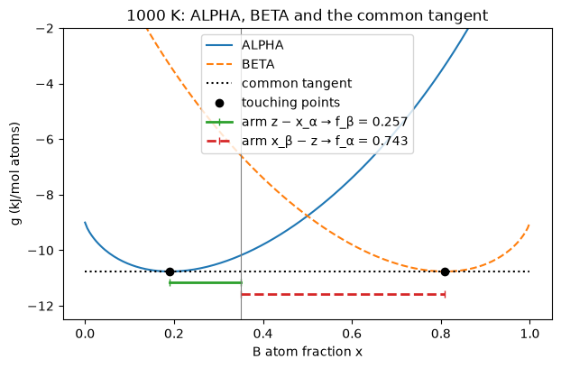

```
 x      g_ALPHA (J/mol)  g_BETA (J/mol)
0.10000    -10502.902      -902.902
0.19104    -10762.730     -3347.690
0.50000     -8763.172     -8763.172
0.80896     -3347.690    -10762.730
0.90000      -902.902    -10502.902
z = 0.35 with the best endpoints: f_alpha = 0.7428, f_beta = 0.2572; the vertical line marks z
```

```python
#@title After your attempt: part A numbers and the common tangent
from course.foundations import binary_family as bf

confirm(float(bf.ideal_properties(1000.0, 0.5, "ALPHA")["GM"]), -8763.172, "Homogeneous ALPHA at x = 0.5", tol=1e-3)
confirm(float(g_alpha(0.5)), -8763.172, "Same value from the formula above", tol=1e-3)
confirm(float(bf.ideal_properties(1000.0, 0.2, "ALPHA")["GM"]), -10760.596, "g_alpha(0.2)", tol=1e-3)
confirm(float(bf.ideal_properties(1000.0, 0.8, "BETA")["GM"]), -10760.596, "g_beta(0.8)", tol=1e-3)
confirm(bf.lever_fraction(0.5, 0.2, 0.8), 0.5, "f_beta for 0.2/0.8 at z = 0.5", tol=1e-12)
confirm(float(g_split(0.5, 0.2, 0.8)), -10760.596, "0.2/0.8 split energy", tol=1e-3)
confirm(bf.lever_fraction(0.35, 0.2, 0.8), 0.25, "f_beta at z = 0.35", tol=1e-12)
confirm(f_beta(0.1, 0.2, 0.8), -1 / 6, "Balance at z = 0.1 (negative, so impossible)", tol=1e-12)

best = bf.ideal_equilibrium(1000.0, 0.5)                 # exact best split at z = 0.5
xa, xb = best["regions"][0]["x"], best["regions"][1]["x"]   # touching compositions in ALPHA and BETA
mu = bf.ideal_derivatives(1000.0, xa, "ALPHA")           # mu_A, mu_B of ALPHA at its touching point
mu_beta = bf.ideal_derivatives(1000.0, xb, "BETA")       # the same for BETA
confirm(xa, 0.19104, "Best ALPHA composition", tol=1e-5)
confirm(xb, 0.80896, "Best BETA composition", tol=1e-5)
confirm(best["GM"], -10762.730, "Best split energy", tol=1e-3)
confirm(float(mu["mu_A"]), -10762.730, "mu_A in ALPHA", tol=1e-3)
confirm(float(mu_beta["mu_A"]), float(mu["mu_A"]), "mu_A equal in BETA", tol=1e-6)
confirm(float(mu_beta["mu_B"]), float(mu["mu_B"]), "mu_B equal in both phases", tol=1e-6)

x = np.linspace(0.0, 1.0, 201)
tangent = float(mu["mu_A"]) + (float(mu["mu_B"]) - float(mu["mu_A"])) * x   # common tangent, J/mol
z_show = 0.35                                              # overall composition used for the lever arms
fb = bf.lever_fraction(z_show, xa, xb)                     # f_beta at z_show
g_at_z = float(mu["mu_A"]) + (float(mu["mu_B"]) - float(mu["mu_A"])) * z_show   # tangent height at z_show
fig, ax = plt.subplots(figsize=(7, 4.2))
ax.plot(x, g_alpha(x) / 1000, "-", label="ALPHA")
ax.plot(x, g_beta(x) / 1000, "--", label="BETA")
ax.plot(x, tangent / 1000, ":", color="k", label="common tangent")
ax.plot([xa, xb], [g_alpha(xa) / 1000, g_beta(xb) / 1000], "ko", label="touching points")
# the two lever arms, drawn 0.4 and 0.8 kJ/mol below the tangent so they do not hide it
ax.plot([xa, z_show], [g_at_z / 1000 - 0.4] * 2, "-|", lw=2, label=f"arm z − x_α → f_β = {fb:.3f}")
ax.plot([z_show, xb], [g_at_z / 1000 - 0.8] * 2, "--|", lw=2, label=f"arm x_β − z → f_α = {1 - fb:.3f}")
ax.axvline(z_show, color="grey", lw=0.8)                  # vertical line at z
ax.set(xlabel="B atom fraction x", ylabel="g (kJ/mol atoms)", title="1000 K: ALPHA, BETA and the common tangent",
       ylim=(-12.5, -2))
ax.legend(fontsize=10, loc="upper center")
plt.show()
print(" x      g_ALPHA (J/mol)  g_BETA (J/mol)")
for xi in (0.1, 0.19104, 0.5, 0.80896, 0.9):
    print(f"{xi:.5f}  {g_alpha(xi):12.3f}  {g_beta(xi):12.3f}")
print(f"z = {z_show} with the best endpoints: f_alpha = {1 - fb:.4f}, f_beta = {fb:.4f}; the vertical line marks z")
```

**Part B cell.** After checking T_c and the 600 K compositions, it draws two panels. *Left:* the mixing part at four temperatures; where a gap exists, the horizontal tangent is drawn in black between its two touching points. *Right:* the gap diagram from 600 K up to 1200 K in steps of 25 K, with T_c marked by a star.

Python details: `np.arange(600.0, 1200.0, 25.0)` gives 600, 625, …, 1175 (it stops before 1200), so 1200 is added with `np.concatenate`. In `(T, *bf.regular_binodal(T)["compositions"], ...)` the `*` unpacks a list into separate entries, so each row becomes (T, x_left, x_right, spinodal_left, spinodal_right). The *spinodal* compositions are where the curve's curvature changes sign; they are stored but not plotted here. `table[:, 1]` takes column 1 of every row; `rows[::4]` takes every fourth row; and `for T, xl, xr, *_ in ...` keeps the first three entries and ignores the rest.

```
✓ T_c = Omega/(2R) reproduces the lesson value.
✓ T_c from the formula above reproduces the lesson value.
✓ Left composition at 600 K reproduces the lesson value.
✓ Right composition at 600 K reproduces the lesson value.
✓ Mixing part at x = 0.5, 600 K reproduces the lesson value.
✓ Same value from the formula above reproduces the lesson value.
```

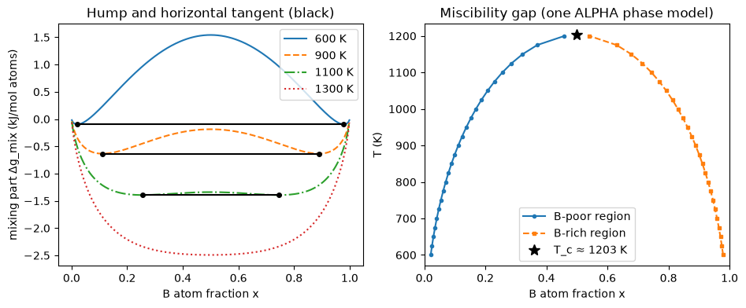

```
T (K)   x_left    x_right
   600  0.02103  0.97897
   700  0.04088  0.95912
   800  0.07009  0.92991
   900  0.11125  0.88875
  1000  0.16914  0.83086
  1100  0.25569  0.74431
  1200  0.45887  0.54113
1202.7  0.5 (the two compositions meet)
```

```python
#@title After your attempt: part B, the hump and the gap diagram
confirm(bf.TC_R1, 1202.718143, "T_c = Omega/(2R)", tol=1e-6)
confirm(OMEGA / (2 * R), bf.TC_R1, "T_c from the formula above", tol=1e-9)
ends_600 = bf.regular_binodal(600.0)["compositions"]
confirm(ends_600[0], 0.021032752, "Left composition at 600 K", tol=1e-9)
confirm(ends_600[1], 0.978967248, "Right composition at 600 K", tol=1e-9)
confirm(float(bf.regular_properties(600.0, 0.5)["GM_mix"]), 1542.096660, "Mixing part at x = 0.5, 600 K", tol=1e-6)
confirm(float(g_mix_regular(0.5, 600.0)), 1542.096660, "Same value from the formula above", tol=1e-6)

x_in = np.linspace(0.001, 0.999, 400)   # avoid the pure ends
fig, (left, right) = plt.subplots(1, 2, figsize=(11, 4))
for T, style in ((600.0, "-"), (900.0, "--"), (1100.0, "-."), (1300.0, ":")):   # K, line style
    left.plot(x_in, g_mix_regular(x_in, T) / 1000, style, label=f"{T:.0f} K")
    ends = bf.regular_binodal(T)["compositions"]
    if ends:                                         # a gap exists at this T
        level = float(g_mix_regular(ends[0], T)) / 1000   # height of the horizontal tangent, kJ/mol
        left.plot(ends, [level, level], "ko-", ms=4)
left.set(xlabel="B atom fraction x", ylabel="mixing part Δg_mix (kJ/mol atoms)",
         title="Hump and horizontal tangent (black)")
left.legend(fontsize=10)

temps = np.concatenate([np.arange(600.0, 1200.0, 25.0), [1200.0]])   # K
# each row: T, x_left, x_right, spinodal_left, spinodal_right
rows = [(T, *bf.regular_binodal(T)["compositions"], *bf.regular_binodal(T)["spinodal"]) for T in temps]
table = np.array(rows)
right.plot(table[:, 1], table[:, 0], "o-", ms=3, label="B-poor region")
right.plot(table[:, 2], table[:, 0], "s--", ms=3, label="B-rich region")
right.plot([0.5], [bf.TC_R1], "k*", ms=10, label=f"T_c ≈ {bf.TC_R1:.0f} K")
right.set(xlabel="B atom fraction x", ylabel="T (K)", title="Miscibility gap (one ALPHA phase model)", xlim=(0, 1))
right.legend(fontsize=10)
plt.show()
print("T (K)   x_left    x_right")
for T, xl, xr, *_ in rows[::4]:          # every fourth row (every 100 K); spinodal columns ignored
    print(f"{T:6.0f}  {xl:.5f}  {xr:.5f}")
print(f"{bf.TC_R1:6.1f}  0.5 (the two compositions meet)")
```

**Part C cell.** It checks the formula in `lens_ends` against the course function `tp.lens_coexistence` at 1400 K, checks that μ_A and μ_B are equal in SOLID and LIQUID there (`tp.lens_mu` returns the pair (μ_A, μ_B) of one phase), and checks the two melting points. It then draws the lens from 1010 K to 1790 K in 10 K steps: above the liquidus everything is LIQUID, below the solidus everything is SOLID, and in between a sample splits into a SOLID and a LIQUID whose compositions are read off the two edges at the same temperature (the dotted tie line at 1400 K).

```
✓ Solidus at 1400 K (formula vs course function) reproduces the lesson value.
✓ Liquidus at 1400 K (formula vs course function) reproduces the lesson value.
✓ mu_A equal in SOLID and LIQUID reproduces the lesson value.
✓ mu_B equal in SOLID and LIQUID reproduces the lesson value.
✓ A melts at 1000 K reproduces the lesson value.
✓ B melts at 1800 K reproduces the lesson value.
```

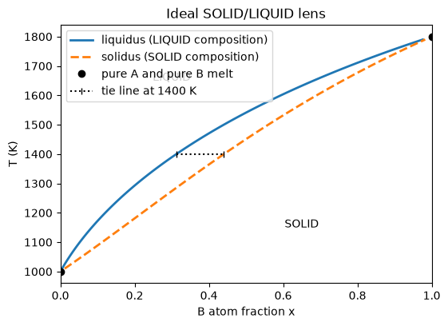

```
T (K)   x_LIQUID  x_SOLID
  1010  0.00454   0.01162
  1110  0.05844   0.12342
  1210  0.12861   0.23119
  1310  0.21650   0.33950
  1410  0.32413   0.45206
  1510  0.45428   0.57232
  1610  0.61069   0.70382
  1710  0.79847   0.85064
```

```python
#@title After your attempt: part C, the melting lens
from course.self_study import two_phase_export as tp

x_s, x_l = tp.lens_coexistence(1400.0)   # (solidus, liquidus) at 1400 K
confirm(lens_ends(1400.0)[0], x_s, "Solidus at 1400 K (formula vs course function)", tol=1e-12)
confirm(lens_ends(1400.0)[1], x_l, "Liquidus at 1400 K (formula vs course function)", tol=1e-12)
mu_s, mu_l = tp.lens_mu("SOLID", x_s, 1400.0), tp.lens_mu("LIQUID", x_l, 1400.0)   # (mu_A, mu_B) in each phase
confirm(mu_s[0], mu_l[0], "mu_A equal in SOLID and LIQUID", tol=1e-6)
confirm(mu_s[1], mu_l[1], "mu_B equal in SOLID and LIQUID", tol=1e-6)
confirm(g0("A", "SOLID", 1000.0), g0("A", "LIQUID", 1000.0), "A melts at 1000 K", tol=1e-9)
confirm(g0("B", "SOLID", 1800.0), g0("B", "LIQUID", 1800.0), "B melts at 1800 K", tol=1e-9)

temps = np.arange(1010.0, 1800.0, 10.0)   # K, 1010 … 1790
lens = np.array([(T, *tp.lens_coexistence(T)) for T in temps])   # columns: T, x_SOLID, x_LIQUID
fig, ax = plt.subplots(figsize=(6, 4.2))
ax.plot(lens[:, 2], lens[:, 0], "-", lw=2, label="liquidus (LIQUID composition)")
ax.plot(lens[:, 1], lens[:, 0], "--", lw=2, label="solidus (SOLID composition)")
ax.plot([0, 1], [1000, 1800], "ko", label="pure A and pure B melt")
ax.plot([x_l, x_s], [1400, 1400], "k:|", label="tie line at 1400 K")
ax.text(0.65, 1150, "SOLID", ha="center")     # label placed inside the single-phase SOLID region
ax.text(0.3, 1650, "LIQUID", ha="center")     # label placed inside the single-phase LIQUID region
ax.set(xlabel="B atom fraction x", ylabel="T (K)", title="Ideal SOLID/LIQUID lens", xlim=(0, 1))
ax.legend(fontsize=10, loc="upper left")
plt.show()
print("T (K)   x_LIQUID  x_SOLID")
for T, xs, xl in lens[::10]:              # every tenth row, i.e. every 100 K
    print(f"{T:6.0f}  {xl:.5f}   {xs:.5f}")
```

**Limits.** All three models are invented and describe no real alloy. Each is a closed bulk sample at fixed T and p with no interfaces, strain or kinetics; whether a split actually forms, and how fast, is a different question. A grid search gives an upper bound that depends on the grid. Close below T_c the course function refuses to report the two compositions rather than guess, and the lens uses ideal solutions only. Real diagrams combine several such regions; step 05 shows a gap and a lens in Cu–Ni.

Worked answers, after your attempt: the worked answer of self-study step 03 and Lessons 5 and 7.

Next: f4b · one phase diagram from scratch, then with pycalphad (optional: the lens of part C built step by step and handed to pycalphad), or straight on to f5 · binary equilibrium in pycalphad.